# Fondamenti di Scienza dei Dati e Laboratorio

## Progetto di **Agostini Matteo** - 01/09/2025 - A.A. 2024/2025

# Introduzione e motivazione

- Scelta del progetto
- Domande che mi sono posto

# Descrizione dei dati

- Dataset utilizzati
- Dati presenti
- Creazione del dataset

Forniti dal sito [Basketball Reference](https://www.basketball-reference.com/), appartenente al gruppo [Sports Reference](https://www.sports-reference.com).

# Struttura dell'analisi

L'analisi delle statistiche si divide in **tre** parti, ed ognuna di queste sarà ripetuta per le tre **ere** che sono state analizzate (2000-2009, 2010-2019, 2020-2025).  
Le tre parti sono le seguenti:

- Analisi di **pattern** comuni nelle statistiche di squadra
- Analisi della composizione del **roster**
- Analisi della differenza nelle statistiche tra la *Regular Season* ed i *Playoff*

## TEAM PATTERNS

Ricerca di elementi in comune analizzando le statistiche di squadra ottenute durante le **82** partite di *Regular Season* per ciascuna stagione.

```
Squadre totali: 295
```

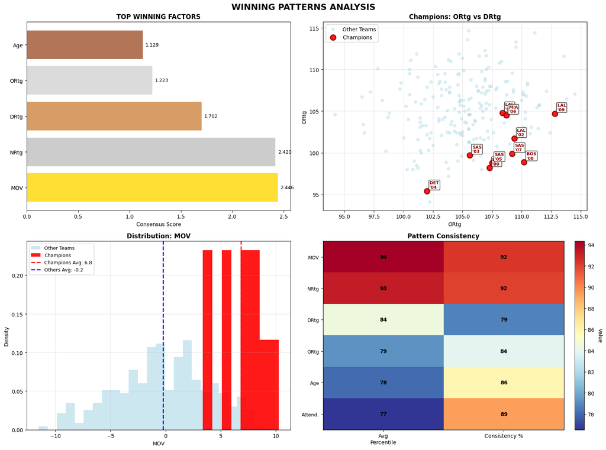

```python
# 2000s
pattern = find_champs_pattern(scraping_functions_team, 2000, 2009)
```

```
Squadre totali: 300
```

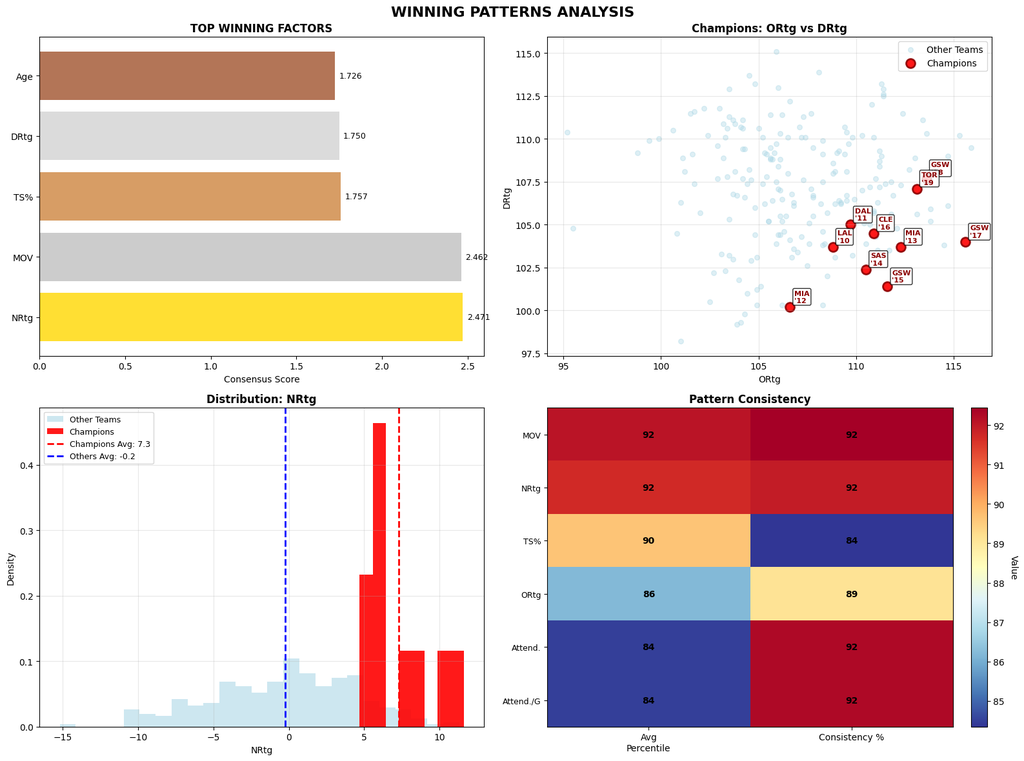

```python
# 2010s
pattern = find_champs_pattern(scraping_functions_team, 2010, 2019)
```

```
Squadre totali: 180
```

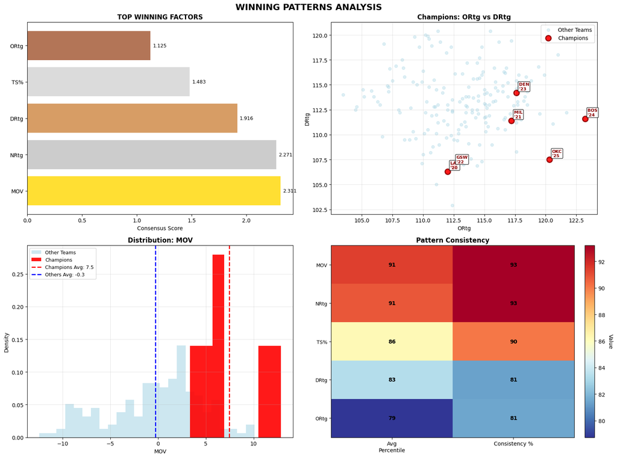

```python
# 2020s
pattern = find_champs_pattern(scraping_functions_team, 2020, 2025)
```

### Osservazioni

Cerchiamo altre risposte...

## ROSTER ANALYSIS

Approfondiamo l'analisi studiando la composizione dei *roster* delle squadre campioni e ricercando delle differenze rispetto al resto delle squadre della lega.

```
CONFRONTO - MEDIE PERCENTUALI:
Archetipo                 Campioni     Lega         Differenza
Superstar/Primary Scorer       7.4%         4.6%        +2.8%
Playmaker                      5.3%         7.6%        -2.3%
3PT Shooter                    8.7%         8.5%        +0.2%
Rim Protector                 14.9%        18.7%        -3.8%
Perimeter Defender            21.8%        22.2%        -0.4%
Stretch Big                   18.7%        17.2%        +1.5%
All-around threat              9.4%        10.2%        -0.8%
Floor General                  6.7%         6.8%        -0.1%
Veteran                        7.0%         4.1%        +2.8%
```

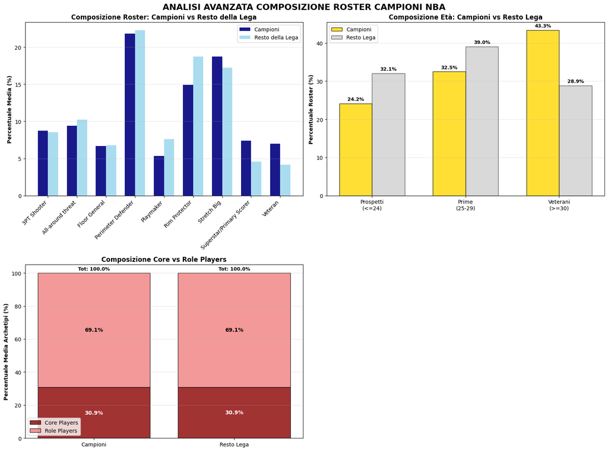

```python
# 2000s
roster = analyze_champions(scraping_functions_roster, 2000, 2009)
```

```
CONFRONTO - MEDIE PERCENTUALI:
Archetipo                 Campioni     Lega         Differenza
Superstar/Primary Scorer       9.0%         5.1%        +3.9%
Playmaker                      5.1%         6.6%        -1.5%
3PT Shooter                    9.5%        10.6%        -1.0%
Rim Protector                 14.6%        16.6%        -2.0%
Perimeter Defender            18.1%        18.4%        -0.3%
Stretch Big                   20.2%        22.9%        -2.7%
All-around threat             11.6%        10.2%        +1.4%
Floor General                  8.6%         6.8%        +1.8%
Veteran                        3.2%         2.8%        +0.4%
```

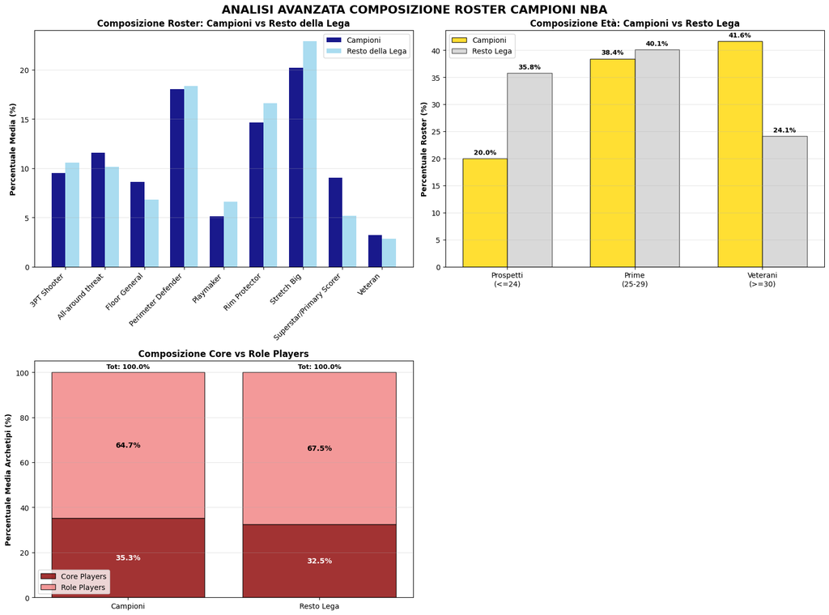

```python
# 2010s
roster = analyze_champions(scraping_functions_roster, 2010, 2019)
```

```
CONFRONTO - MEDIE PERCENTUALI:
Archetipo                 Campioni     Lega         Differenza
Superstar/Primary Scorer       8.0%         6.5%        +1.5%
Playmaker                      4.7%         5.6%        -0.9%
3PT Shooter                   12.7%        12.4%        +0.3%
Rim Protector                  9.2%        13.4%        -4.2%
Perimeter Defender            15.7%        13.8%        +1.9%
Stretch Big                   24.2%        25.5%        -1.3%
All-around threat             11.1%        10.4%        +0.7%
Floor General                 11.5%        10.5%        +1.0%
Veteran                        2.9%         2.0%        +0.9%
```

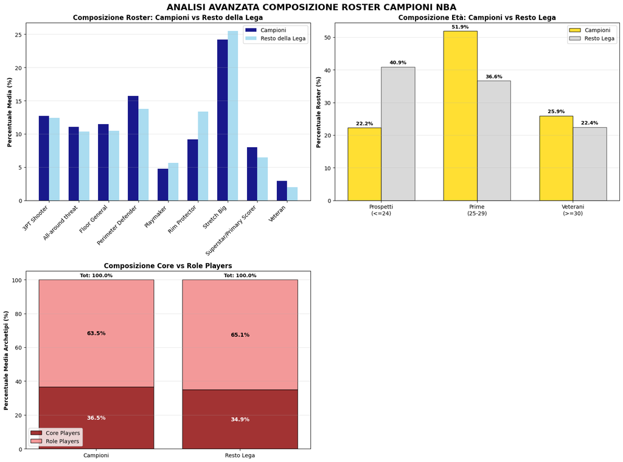

```python
# 2020s
roster = analyze_champions(scraping_functions_roster, 2020, 2025)
```

### Osservazioni

La differenza principale è nella presenza di **superstar**, con un valore medio di +2.73%.  
Altre considerazioni sulle squadre che hanno vinto il titolo:

- Non è considerata importante la figura di un 'Rim Protector' (-3.34% di media)
- Recentemente, rilevanti i giocatori di tipo 'Perimeter Defender' (+1.9%)

Analisi dell'**età**:

- Nel periodo 2000-2019 le squadre **campioni** avevano +15.95% di veterani in media (a discapito dei giovani)
- Nelle ultime **sei** stagioni, i roster vincenti sono composti da pochi *giovani*, pochi *veterani* (ma +3.5% della *media della lega*) e la maggioranza del roster (**51.9%**) è composto da giocatori nel loro **prime** agonistico

## PLAYOFF ANALYSIS

Infine, valutiamo le differenze tra i campioni e le altre squadre che hanno partecipato ai *Playoff*.  
Quali elementi hanno permesso loro di ottenere l'anello?

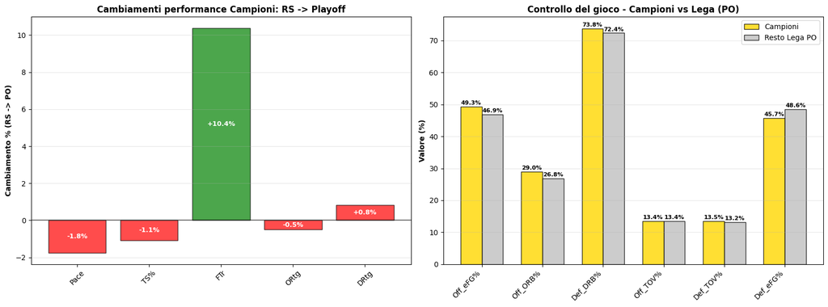

```
CAMPIONI vs LEGA - PLAYOFF:
(Le percentuali indicano la differenza relativa tra la media dei campioni
e la media del resto della lega nei playoff)

Statistica         | Campioni     | Lega         | Differenza
----------------------------------------------------------------------
NRtg               | 6.1          | -3.4         | +9.56 punti
Off_ORB%           | 29.0         | 26.8         | +2.21 punti (+8.2%)
Def_eFG%           | 45.7%        | 48.6%        | -0.03 punti (-5.9%)
Off_eFG%           | 49.3%        | 46.9%        | +0.02 punti (+5.0%)
TS%                | 53.6%        | 51.8%        | +0.02 punti (+3.4%)
Def_DRB%           | 73.8         | 72.4         | +1.37 punti (+1.9%)
Def_TOV%           | 13.5         | 13.2         | +0.25 punti (+1.9%)
Pace               | 89.4         | 89.2         | +0.23 punti (+0.3%)
Off_TOV%           | 13.4         | 13.4         | -0.02 punti (-0.2%)
```

```python
# 2000s
playoff = analyze_playoff_performance(scraping_functions_PO, 2000,2009)
```

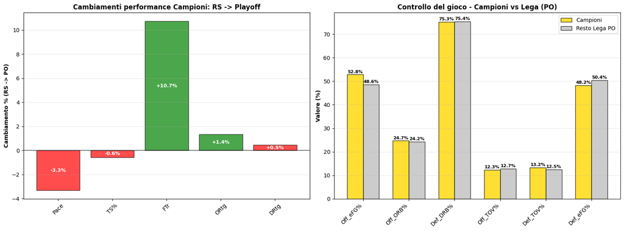

```
CAMPIONI vs LEGA - PLAYOFF:
(Le percentuali indicano la differenza relativa tra la media dei campioni
e la media del resto della lega nei playoff)

Statistica         | Campioni     | Lega         | Differenza
----------------------------------------------------------------------
NRtg               | 8.3          | -3.5         | +11.81 punti
Off_eFG%           | 52.8%        | 48.6%        | +0.04 punti (+8.6%)
TS%                | 56.8%        | 52.9%        | +0.04 punti (+7.4%)
Def_TOV%           | 13.2         | 12.5         | +0.74 punti (+5.9%)
Def_eFG%           | 48.2%        | 50.4%        | -0.02 punti (-4.4%)
Off_TOV%           | 12.3         | 12.7         | -0.40 punti (-3.1%)
Off_ORB%           | 24.7         | 24.2         | +0.46 punti (+1.9%)
Pace               | 92.1         | 92.3         | -0.22 punti (-0.2%)
Def_DRB%           | 75.3         | 75.4         | -0.12 punti (-0.2%)
```

```python
# 2010s
playoff = analyze_playoff_performance(scraping_functions_PO, 2010,2019)
```

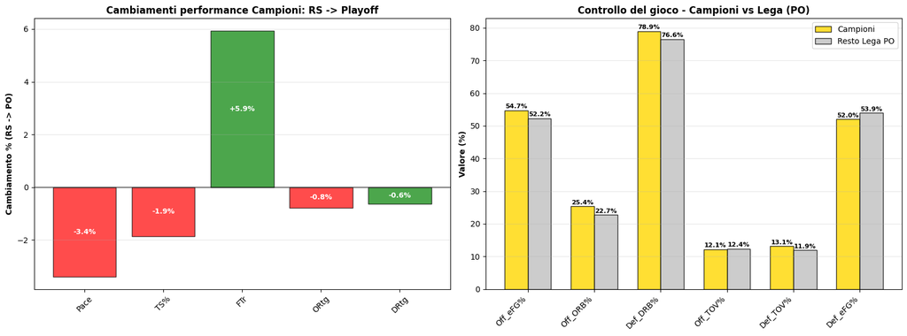

```
CAMPIONI vs LEGA - PLAYOFF:
(Le percentuali indicano la differenza relativa tra la media dei campioni
e la media del resto della lega nei playoff)

Statistica         | Campioni     | Lega         | Differenza
----------------------------------------------------------------------
NRtg               | 7.2          | -3.8         | +11.01 punti
Off_ORB%           | 25.4         | 22.7         | +2.64 punti (+11.6%)
Def_TOV%           | 13.1         | 11.9         | +1.22 punti (+10.3%)
Off_eFG%           | 54.7%        | 52.2%        | +0.02 punti (+4.7%)
Def_eFG%           | 52.0%        | 53.9%        | -0.02 punti (-3.6%)
TS%                | 58.0%        | 56.1%        | +0.02 punti (+3.5%)
Def_DRB%           | 78.9         | 76.6         | +2.37 punti (+3.1%)
Off_TOV%           | 12.1         | 12.4         | -0.26 punti (-2.1%)
Pace               | 96.1         | 95.7         | +0.36 punti (+0.4%)
```

```python
# 2020s
playoff = analyze_playoff_performance(scraping_functions_PO, 2020,2025)
```

### Osservazioni

Nei *PO*, differenza tra la media dei campioni e la media del resto della lega:

- **Controllo** del gioco: ORB% (+7.23%), DRB% (+1.7%), Off_TOV% (-1.73%)
- **Difesa**: Def_eFG% (-4.63%), Def_TOV% (+6.03%)
- **Efficienza**: TS% (+4.76%), Off_eFG% (+6.1%)

# Conclusioni

Quali elementi comuni condividono le squadre che sono riuscite a vincere il titolo?  
L'analisi condotta sui dati delle stagioni NBA dal 2000 al 2025 rivela che il successo si basa su una combinazione di *efficienza offensiva*, *costanza difensiva* e una matura *composizione del roster*.

- Alto **MOV** e **NRtg** (alto **ORtg** e basso **DRtg**). Dominio su entrambi i lati del campo
- **Efficienza** totale al tiro, dal campo e dalla lunetta
- Roster versatile con **esperienza** e **star power**
- **Winning DNA**: capacità di controllare il gioco e rimanere lucidi (specialmente ai *PO*)
- Controllo dei **rimbalzi**
- **Difesa** che spinge a fare errori e prendere tiri contrastati/affrettati